# Figures: comparative unproductive splicing across seven vertebrate species

Author

Benjamin Fair

Published

August 25, 2026

## What this notebook does

This rebuilds every data panel of the paper’s comparative-splicing figures. It reads **only** the plot-ready tables in `output/` and the metadata in `data/`, so it runs in seconds and needs none of the pipeline’s intermediates.

Those tables are produced by `code/rules/PlotData.smk`, which reduces roughly 9 GB of pipeline output to under 4 MB. They are shipped with the project, so the figures reproduce without re-running anything; `snakemake all_plot_data all_supplement_tables` regenerates them from pipeline intermediates, and `snakemake all` rebuilds those from raw sequencing data.

### What is shipped rather than computed

Three groups of files are shipped as inputs in `data/` rather than being produced by a rule. Each is small, and each is here for a reason worth stating:

- **`data/conservation/`** — per-base PhyloP for the *SCN8A* and *ARHGAP17* loci, and the dN/dS + mean-PhyloP tables for cassette-exon trios (about 2 MB total). These are the small end products of the 100-way multiz vertebrate alignment, which needs roughly 1.5 TB of scratch and days of compute to process. Shipping them is what lets panels d, e and f of the conserved-AS figure reproduce in seconds. The rules that regenerate them are available as the non-default target `snakemake all_dnds`; **that chain is the one part of the workflow not exercised by the dry-run check**, so treat it as the least-tested path.
- **`data/Ensembl.TranscriptInfo.tsv.gz`** and **`data/Ensembl.GeneHumanHomologs.tsv.gz`** — gene/transcript biotypes and human orthologs. biomaRt queries a live service, and the UCSC annotation tracks these have to agree with are frozen snapshots (Ensembl v110 for mm39), so a re-fetch is not guaranteed to reproduce them. `snakemake all_refresh_annotations` fetches a fresh copy into `code/scratch/` for comparison rather than overwriting the shipped one.
- **The supplementary tables** — including `20260820_SupplementalTable_Contrasts.tsv`, which lists every contrast the paper used along with the libraries in each arm. That file is the authority for the contrast definitions: the leafcutter group files are generated from it by `rule MakeContrastGroupFiles`, and the differential-splicing targets are restricted to the contrasts it names.

Everything under `code/scratch/` is by contrast disposable: parse-time derivatives (an aspera manifest, an absolute-path rewrite of `samples.tsv`) and rule intermediates.

The published figures are multi-panel composites assembled by hand. What is rebuilt here are the individual data panels. Two panels are graphical assets rather than plots and are not rebuilt: the *ARHGAP17* gene track and the *SCN8A* exon schematic.

### Panel index

| Panel | Shows | Reads |
| --- | --- | --- |
| Fig 3a | Annotated transcripts per gene, by transcript productivity | `DataToPlot.TranscriptsPerGene*` |
| Fig 3b | Percent of unique junctions by productivity and annotation status | `DataToPlot.JuncClassTallies` |
| Fig 3c | Percent unproductive reads, juvenile vs adult testis | `DataToPlot.Testis.Percent.UP` |
| Fig 3d | ΔPSI vs Δexpression, adult brain vs adult kidney | `DataForReplotting_BetaBeta_AdultBrainKidney` |
| Fig 3f | *ARHGAP17* unproductive junction across testis development | `DataForReplotting_ConservedAS_Examples` |
| FigS20 | Percent unproductive reads, every species/tissue, across development | `DataToPlot.AllTissues.Percent.UP` |
| FigS21a–c | Fig 3a/3b equivalents across all three annotation sources | as above |
| FigS22a | *UPF3A*/*UPF3B* across testis maturation | `DataForReplotting_NMDFactorExpression` |
| FigS23a | ΔPSI vs Δexpression, juvenile vs adult testis | `DataForReplotting_BetaBeta_JuvenileAdultTestis` |
| FigS23b | Splicing–expression coupling, every contrast and species | `DataToPlot.ContrastSummaries` |
| FigS24a | Conserved-event counts after each successive filter | `DataToPlot.ConservedEventCascade` |
| FigS24c | *SCN8A* exon 18N splicing and host-gene expression | `DataForReplotting_ConservedAS_Examples` |
| FigS24d | *SCN8A* exon conservation by codon position | `DataForReplotting_SCN8A_PhyloP` |
| FigS24e | dN/dS vs PhyloP for cassette-exon trios | `DataToPlot.dNdS_PhyloP_ExonTrios` |
| FigS24f | *ARHGAP17* flanking intronic conservation | `DataForReplotting_ARHGAP17_FlankingPhyloP` |

### Definitions used throughout

**Junction productivity.** leafcutter2 assigns four boolean flags per junction, combined as `1*UTR + 2*Coding + 4*Annot + 8*GencodePC`. Codes 1 and 5 are near-UTR (“NE”), codes 0 and 4 are unproductive (“UP”), everything else is productive (“PR”); unclassified junctions count as productive. Near-UTR junctions are excluded from every productive/unproductive split. The conserved-event cascade uses a coarser definition — `not (Coding or GencodePC)` — which folds near-UTR junctions in with the unproductive ones.

**One event per cluster.** Differential-splicing results are per junction, but the panels count events. Within each leafcutter cluster one representative junction is kept: the unproductive junction with the largest |ΔPSI| if the cluster has one, otherwise the productive junction with the largest |ΔPSI|. Clusters must also pass `p.adjust < 0.05` and `|ΔPSI| > 0.05`. This reduction happens in the export rules, upstream of this notebook.

**R conventions reproduced in Python.** `scipy.stats.mannwhitneyu` defaults to the asymptotic approximation while R’s `wilcox.test` uses the exact null distribution when there are no ties, so `wilcox_p` reproduces R’s rule. `bh` reproduces `p.adjust(method="BH")` and `r_format_pval` reproduces `format.pval`, which formats p-value labels per facet rather than globally.

## Setup

```python
import os

import numpy as np
import pandas as pd
import matplotlib
import matplotlib.pyplot as plt
import seaborn as sns
from scipy.stats import mannwhitneyu, ttest_ind, norm

OUT = "../output"
DATA = "../data"
FIGDIR = "figures"
os.makedirs(FIGDIR, exist_ok=True)

SPECIES = ["Human", "Macaque", "Mouse", "Rat", "Rabbit", "Opossum", "Chicken"]
SPIDX = {sp: i for i, sp in enumerate(SPECIES)}
SRC_ORDER = ["Gencode", "Ensembl", "RefSeq"]
# the annotation source used for each species in the main figures
MAIN_GTF = {"Human": "Gencode", "Mouse": "Gencode", "Rat": "RefSeq", "Chicken": "Ensembl",
            "Opossum": "Ensembl", "Macaque": "Ensembl", "Rabbit": "Ensembl"}

# One size for every annotation, so nothing is much smaller than anything else when the
# figure is rescaled by hand. Smallest text is 6.5 pt against 9 pt axis text.
SMALL_TXT, AXIS_TXT, LEG_TXT = 6.5, 9.0, 7.5

GROUP_ORDER = ["Productive, annotated", "Productive, unannotated",
               "Unproductive, annotated", "Unproductive, unannotated"]
GROUP_COL = {"Productive, annotated": "#1f78b4", "Productive, unannotated": "#a6cee3",
             "Unproductive, annotated": "#e31a1c", "Unproductive, unannotated": "#fb9a99"}
CODE_COL = {"Productive": "#1f78b4", "Unproductive": "#e31a1c"}
TX_COL = {"Productive": "#377eb8", "Unproductive": "#e41a1c"}
STAGE_COL = {"Early embryo testis": "#1b9e77", "Juvenile testis": "#d95f02",
             "Adult testis": "#7570b3", "Juvenile": "#d95f02", "Adult": "#7570b3"}
DARK2 = ["#1B9E77", "#D95F02", "#7570B3"]        # RColorBrewer Dark2, first three
XT_LAB = ["1", "", "", "", "5", "", "", "", "", ">10"]

NEW_TESTIS_NAME = "Juvenile Testis v Adult Testis"


def savefig(fig, name):
    p = os.path.join(FIGDIR, name)
    fig.savefig(p, bbox_inches="tight")
    return p


# Source data: one entry per panel, collected as the notebook runs and written to a single
# multi-tab spreadsheet (one tab per panel, main and supplemental together) at the end.
SOURCE_DATA = {}


def record_source(panel, df):
    """Stash the exact table behind a panel's plot, keyed by its panel label."""
    assert panel not in SOURCE_DATA, f"duplicate source-data panel label: {panel}"
    SOURCE_DATA[panel] = df.reset_index(drop=True).copy()
```

## Shared helpers

```python
def wilcox_p(a, b, alternative="two-sided"):
    """R's wilcox.test rule: exact when small and untied, asymptotic otherwise."""
    a, b = np.asarray(a, float), np.asarray(b, float)
    ties = len(np.unique(np.concatenate([a, b]))) < len(a) + len(b)
    method = "asymptotic" if (ties or len(a) >= 50 or len(b) >= 50) else "exact"
    return mannwhitneyu(a, b, alternative=alternative, method=method).pvalue


def bh(p):
    """p.adjust(p, method='BH')"""
    p = np.asarray(p, float); n = len(p); o = np.argsort(p); r = np.empty(n)
    r[o] = np.minimum.accumulate((p[o] * n / np.arange(1, n + 1))[::-1])[::-1]
    return np.minimum(r, 1)


def pfmt(p):
    if p >= 1e-3:
        return f"{p:.3f}"
    e = int(np.floor(np.log10(p))); m = p / 10 ** e
    if m >= 9.5:
        m, e = 1.0, e + 1
    return f"{m:.0f}e{e:+03d}"


def pval_fmt(p, digits=2):
    if p == 0 or not np.isfinite(p):
        return "NA"
    return f"{p:.{digits}g}" if p >= 1e-4 else f"{p:.{digits-1}e}".replace("e-0", "e-")


def rfmt(p):
    return f"{p:.0e}".replace("e-0", "e-") if p < 1e-3 else f"{p:.3f}"


def _signif(x, d):
    x = np.asarray(x, float)
    e = np.floor(np.log10(np.abs(np.where(x != 0, x, 1))))
    return np.round(x / 10.0 ** e, d - 1) * 10.0 ** e


def r_format_pval(vals, digits=1):
    """Emulate R's format.pval(x, digits) on a vector.

    R splits at exponent -3, then within each subset uses a COMMON number of decimals -- set
    so the smallest element still shows `digits` significant figures, using the value AFTER
    rounding -- and picks fixed or scientific by whichever is not wider.
    """
    vals = np.asarray(vals, float)
    out = np.empty(len(vals), dtype=object)
    expo = np.floor(np.log10(np.where(vals > 0, vals, 1e-50)))
    for mask in (expo >= -3, expo < -3):
        if not mask.any():
            continue
        sub = vals[mask]
        dec = int(max(digits - 1 - np.floor(np.log10(_signif(sub, digits)))))
        out[mask] = ([f"%.{dec}f" % v for v in sub] if 2 + dec <=
                     max(len(f"%.{digits-1}e" % v) for v in sub)
                     else [f"%.{digits-1}e" % v for v in sub])
    return list(out)


def shade(ax, n=7):
    """Alternating grey species bands."""
    for i in range(n):
        if i % 2 == 1:
            ax.axvspan(i - 0.5, i + 0.5, color="0.90", zorder=0, lw=0)
```

`seaborn.swarmplot` hardcodes each swarm’s width to its dodge slot (`0.8 / n_hue_levels`), which makes neighbouring groups touch and has no user-facing knob. These lay the beeswarm out directly so the width can be capped. Axis limits must be set *before* calling `draw_swarm`, because the layout depends on the data-to-pixel scale.

```python
def _beeswarm_px(y_px, d_px, max_half_px):
    offs = np.zeros(len(y_px)); placed = []
    for idx in np.argsort(y_px):
        yi = y_px[idx]
        forbidden = []
        for px, py in placed:
            dy = abs(yi - py)
            if dy < d_px:
                dx = np.sqrt(d_px ** 2 - dy ** 2)
                forbidden.append((px - dx, px + dx))
        chosen = 0.0
        for cand in sorted({0.0, *[b for iv in forbidden for b in iv]}, key=abs):
            if all(not (lo + 1e-9 < cand < hi - 1e-9) for lo, hi in forbidden):
                chosen = cand; break
        chosen = float(np.clip(chosen, -max_half_px, max_half_px))
        placed.append((chosen, yi)); offs[idx] = chosen
    return offs


def draw_swarm(ax, xcenter, yvals, color, size_pt, max_width, zorder=3):
    """One beeswarm centred at xcenter, never wider than max_width (x data units)."""
    yvals = np.asarray(yvals, float)
    if len(yvals) == 0:
        return
    fig = ax.figure; fig.canvas.draw()
    t = ax.transData; o = t.transform((0, 0))
    ux = t.transform((1, 0))[0] - o[0]
    uy = t.transform((0, 1))[1] - o[1]
    offs = _beeswarm_px(yvals * uy, size_pt * fig.dpi / 72.0, max_width / 2 * ux)
    ax.scatter(xcenter + offs / ux, yvals, s=size_pt ** 2, color=color,
               linewidths=size_pt / 10, edgecolors="none", zorder=zorder)
```

Sample groups come out of the supplementary contrast table, so the figures cannot drift from the file the paper ships.

```python
contrasts = pd.read_csv(f"{DATA}/20260820_SupplementalTable_Contrasts.tsv", sep="\t")

def samples_from_table(contrast_name, groupnum=None):
    d = contrasts[contrasts.ContrastName == contrast_name]
    recs = []
    for _, r in d.iterrows():
        for gi, col in [(1, "SamplesInGroup1"), (2, "SamplesInGroup2")]:
            if groupnum is not None and gi != groupnum:
                continue
            if isinstance(r[col], str):
                recs += [{"Species": r.Species, "sample": s, "GroupNum": gi}
                         for s in r[col].split(", ")]
    return pd.DataFrame(recs)


def contrast_n_sig(contrast_name, species, coding):
    """n_sig_{productive,unproductive}_ds_leafcutter_clusters straight from the contrast table."""
    col = f"n_sig_{coding.lower()}_ds_leafcutter_clusters"
    d = contrasts[(contrasts.ContrastName == contrast_name) & (contrasts.Species == species)]
    return int(d[col].iloc[0])


contrasts[["ContrastGroup", "ContrastName", "Species"]].head()
```

|  | ContrastGroup | ContrastName | Species |
| --- | --- | --- | --- |
| 0 | Adult tissues | Adult Brain v Adult Cerebellum | Chicken |
| 1 | Adult tissues | Adult Brain v Adult Cerebellum | Human |
| 2 | Adult tissues | Adult Brain v Adult Cerebellum | Macaque |
| 3 | Adult tissues | Adult Brain v Adult Cerebellum | Mouse |
| 4 | Adult tissues | Adult Brain v Adult Cerebellum | Opossum |

The splicing-vs-expression Spearman test is run once per (contrast, species, coding class) — every “well-powered” (`n >= 100`) row of `DataToPlot.ContrastSummaries.tsv.gz`, which spans every contrast in the supplementary contrast table, developmental and adult-tissue-pair alike. Fig 3d and FigS23a each highlight one specific contrast from that same family, so their P.adj is computed by Benjamini-Hochberg over the *whole* 417-test family, not just the 4 tests shown in that one panel — the two are looked up from one shared correction rather than each running its own local `p.adjust`.

```python
contrast_summaries_powered = pd.read_csv(f"{OUT}/DataToPlot.ContrastSummaries.tsv.gz", sep="\t")
contrast_summaries_powered = contrast_summaries_powered[
    contrast_summaries_powered.n >= 100].copy()
contrast_summaries_powered["p_adj"] = bh(contrast_summaries_powered.p.values)


def contrast_p_adj(tissue, species, coding):
    """BH-adjusted P for one (tissue, species, coding) test, corrected across all 417 tests."""
    d = contrast_summaries_powered[
        (contrast_summaries_powered.Tissue == tissue)
        & (contrast_summaries_powered.Species == species)
        & (contrast_summaries_powered.Coding == coding)]
    return d.p_adj.iloc[0]


print(f"{len(contrast_summaries_powered)} well-powered tests in the shared correction family")
```

```
417 well-powered tests in the shared correction family
```

# Annotated transcripts per gene

Restricted to protein-coding genes; a transcript counts as unproductive when its own biotype is not `protein_coding`.

```python
hist = pd.read_csv(f"{OUT}/DataToPlot.TranscriptsPerGene.tsv.gz", sep="\t")
tx_totals = pd.read_csv(f"{OUT}/DataToPlot.TranscriptsPerGene.Totals.tsv.gz", sep="\t")
tx_totals
```

|  | AnnotationSource | Species | NumCoding | NumNoncoding | Total | nGenes |
| --- | --- | --- | --- | --- | --- | --- |
| 0 | Ensembl | Chicken | 28444 | 0 | 28444 | 16878 |
| 1 | Ensembl | Human | 99431 | 53845 | 153276 | 22446 |
| 2 | Ensembl | Macaque | 48770 | 0 | 48770 | 21761 |
| 3 | Ensembl | Mouse | 66153 | 35705 | 101858 | 21684 |
| 4 | Ensembl | Opossum | 22310 | 0 | 22310 | 21327 |
| 5 | Ensembl | Rabbit | 41055 | 0 | 41055 | 20612 |
| 6 | Gencode | Human | 89610 | 81829 | 171439 | 20089 |
| 7 | Gencode | Mouse | 58507 | 43122 | 101629 | 21700 |
| 8 | RefSeq | Chicken | 49668 | 3053 | 52721 | 17444 |
| 9 | RefSeq | Human | 139092 | 12351 | 151443 | 20627 |
| 10 | RefSeq | Macaque | 67977 | 3331 | 71308 | 21096 |
| 11 | RefSeq | Mouse | 98005 | 10857 | 108862 | 22864 |
| 12 | RefSeq | Rabbit | 38463 | 813 | 39276 | 20303 |
| 13 | RefSeq | Rat | 74754 | 4596 | 79350 | 22228 |

Annotation sources differ enormously in how many unproductive isoforms they carry: Ensembl annotates none at all for macaque, rabbit, opossum or chicken.

## Fig 3a — transcripts per gene, main annotation

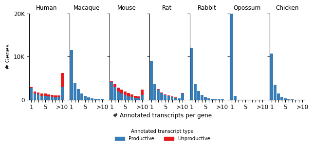

Figure 1: Unproductive transcript isoforms are not annotated in most species.

```python
def tx_panel(ax, sub):
    sub = sub.set_index("Grp").reindex(range(1, 11)).fillna(0.0)
    x = np.arange(1, 11)
    ax.bar(x, sub.BarCoding.values, width=0.85, color=TX_COL["Productive"], lw=0)
    ax.bar(x, sub.BarNoncoding.values, bottom=sub.BarCoding.values, width=0.85,
           color=TX_COL["Unproductive"], lw=0)
    ax.set_ylim(0, 20e3); ax.set_yticks([0, 10e3, 20e3])
    ax.set_yticklabels(["0", "10K", "20K"])
    ax.set_xticks(x); ax.set_xticklabels(XT_LAB); ax.set_xlim(0.4, 10.6)
    ax.tick_params(axis="both", labelsize=AXIS_TXT)
    sns.despine(ax=ax)


fig, axes = plt.subplots(1, 7, figsize=(7.6, 2.4), sharey=True,
                         gridspec_kw={"wspace": 0.15})
for ax, sp in zip(axes, SPECIES):
    tx_panel(ax, hist[(hist.Species == sp) & (hist.AnnotationSource == MAIN_GTF[sp])])
    ax.set_title(sp, fontsize=AXIS_TXT)
    if ax is not axes[0]:
        ax.tick_params(labelleft=False)
axes[0].set_ylabel("# Genes", fontsize=AXIS_TXT)
fig.supxlabel("# Annotated transcripts per gene", fontsize=AXIS_TXT, y=-0.06)
fig.legend(handles=[plt.Rectangle((0, 0), 1, 1, color=TX_COL[k]) for k in TX_COL],
           labels=list(TX_COL), loc="lower center", bbox_to_anchor=(0.5, -0.30),
           ncol=2, frameon=False, fontsize=LEG_TXT,
           title="Annotated transcript type", title_fontsize=LEG_TXT)
savefig(fig, "Fig3a_TranscriptsPerGene_MainGtfs.pdf")
record_source("Fig3a", hist[[MAIN_GTF[s] == a
                             for s, a in zip(hist.Species, hist.AnnotationSource)]])
```

## FigS21a — transcripts per gene, all annotation sources

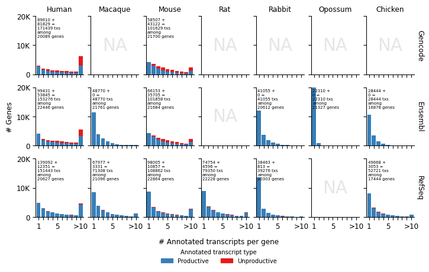

Figure 2: Transcripts per gene across all three annotation sources.

```python
fig, axes = plt.subplots(3, 7, figsize=(8.6, 4.6), sharey=True, sharex=True,
                         gridspec_kw={"wspace": 0.15, "hspace": 0.22})
for ri, src in enumerate(SRC_ORDER):
    for ci, sp in enumerate(SPECIES):
        ax = axes[ri, ci]
        sub = hist[(hist.Species == sp) & (hist.AnnotationSource == src)]
        if len(sub) == 0:
            ax.text(0.5, 0.5, "NA", transform=ax.transAxes, ha="center", va="center",
                    fontsize=22, color="0.90", zorder=0)
            ax.set_ylim(0, 20e3); ax.set_yticks([0, 10e3, 20e3])
            ax.set_yticklabels(["0", "10K", "20K"])
            ax.set_xticks(np.arange(1, 11)); ax.set_xticklabels(XT_LAB)
            ax.set_xlim(0.4, 10.6)
            ax.tick_params(axis="both", labelsize=AXIS_TXT); sns.despine(ax=ax)
        else:
            tx_panel(ax, sub)
            s = tx_totals[(tx_totals.Species == sp)
                          & (tx_totals.AnnotationSource == src)].iloc[0]
            ax.text(0.03, 0.97,
                    f"{s.NumCoding} +\n{s.NumNoncoding} =\n{s.Total} txs\n"
                    f"among\n{s.nGenes} genes",
                    transform=ax.transAxes, ha="left", va="top", fontsize=5.2)
        if ri == 0:
            ax.set_title(sp, fontsize=AXIS_TXT)
        if ci == 6:
            ax2 = ax.twinx(); ax2.set_yticks([])
            ax2.set_ylabel(src, fontsize=AXIS_TXT, rotation=-90, labelpad=12)
            for s_ in ax2.spines.values():
                s_.set_visible(False)
axes[1, 0].set_ylabel("# Genes", fontsize=AXIS_TXT)
fig.supxlabel("# Annotated transcripts per gene", fontsize=AXIS_TXT, y=0.0)
fig.legend(handles=[plt.Rectangle((0, 0), 1, 1, color=TX_COL[k]) for k in TX_COL],
           labels=list(TX_COL), loc="lower center", bbox_to_anchor=(0.5, -0.09),
           ncol=2, frameon=False, fontsize=LEG_TXT,
           title="Annotated transcript type", title_fontsize=LEG_TXT)
savefig(fig, "FigS_AltGtfs_a_TranscriptsPerGene.pdf")
record_source("FigS21A", hist.merge(
    tx_totals, on=["Species", "AnnotationSource"], suffixes=("", "_Total")))
```

# Junction productivity classification

Two views of the same tally: the fraction of *unique junctions* in each class, and the fraction of *junction reads*. Reads are overwhelmingly productive-annotated, so that view needs a broken axis.

```python
tal = pd.read_csv(f"{OUT}/DataToPlot.JuncClassTallies.tsv.gz", sep="\t")
tal["Group"] = (pd.Series(np.where(tal.IsProd, "Productive, ", "Unproductive, "),
                          index=tal.index)
                + np.where(tal.Annot, "annotated", "unannotated"))
uniq_p = tal[tal.Metric == "UniqueJunctions"]
reads_p = tal[tal.Metric == "JunctionReads"]


def main_gtf_only(d):
    return d[[MAIN_GTF[s] == a for s, a in zip(d.Species, d.AnnotationSource)]]


def facet_piv(d, sp):
    return (d[d.Species == sp]
            .pivot_table(index="AnnotationSource", columns="Group", values="Percent")
            .reindex(SRC_ORDER).reindex(columns=GROUP_ORDER))


piv_uniq = (main_gtf_only(uniq_p)
            .pivot_table(index="Species", columns="Group", values="Percent")
            .reindex(SPECIES)[GROUP_ORDER])
piv_uniq.round(2)
```

| Group Species | Productive, annotated | Productive, unannotated | Unproductive, annotated | Unproductive, unannotated |
| --- | --- | --- | --- | --- |
| Human | 75.22 | 11.04 | 2.93 | 10.82 |
| Macaque | 67.79 | 12.37 | NaN | 19.85 |
| Mouse | 79.52 | 9.11 | 1.93 | 9.45 |
| Rat | 80.41 | 8.44 | 0.61 | 10.53 |
| Rabbit | 69.02 | 13.57 | NaN | 17.41 |
| Opossum | 64.33 | 13.59 | NaN | 22.08 |
| Chicken | 67.83 | 11.72 | NaN | 20.45 |

Only human, mouse and rat have any *annotated* unproductive junctions — Ensembl carries no NMD biotype for the other four species, which is why the dark-red sliver appears in only three bars.

## Fig 3b — percent unique junctions, main annotation

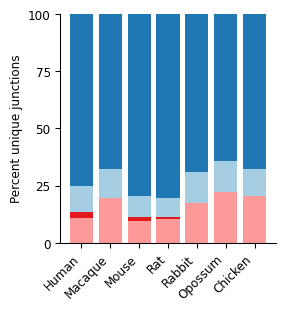

Figure 3: A similar percent of splice junctions is classified as unproductive in every species.

```python
def stacked_panel(ax, piv, ylab):
    piv = piv.fillna(0.0)
    x = np.arange(len(piv)); bottom = np.zeros(len(piv))
    for grp in reversed(GROUP_ORDER):          # bottom-up: unproductive-unannotated first
        ax.bar(x, piv[grp].values, bottom=bottom, width=0.8,
               color=GROUP_COL[grp], label=grp, lw=0)
        bottom += piv[grp].values
    ax.set_xticks(x); ax.set_xticklabels(piv.index)
    ax.set_ylabel(ylab, fontsize=AXIS_TXT)
    ax.tick_params(axis="both", labelsize=AXIS_TXT)
    ax.tick_params(axis="x", labelrotation=45)
    for lab in ax.get_xticklabels():
        lab.set_ha("right")
    sns.despine(ax=ax)


fig, ax = plt.subplots(figsize=(2.9, 3.1))
stacked_panel(ax, piv_uniq, "Percent unique junctions")
ax.set_ylim(0, 100); ax.set_yticks([0, 25, 50, 75, 100])
savefig(fig, "Fig3b_PercentUniqueJuncs_MainGtfs.pdf")
record_source("Fig3b", piv_uniq.reset_index())
```

## FigS21b,c — percent unique junctions / junction reads, all annotation sources

```python
def faceted_stacked(d, ylab, fname, broken=False, figsize=(7.2, 3.4)):
    if broken:
        fig, axrows = plt.subplots(2, len(SPECIES), figsize=figsize, sharex="col",
                                   gridspec_kw={"height_ratios": [1, 2.2],
                                                "hspace": 0.10, "wspace": 0.18})
        rows = [axrows[0], axrows[1]]
    else:
        fig, row = plt.subplots(1, len(SPECIES), figsize=figsize, sharey=True,
                                gridspec_kw={"wspace": 0.18})
        rows = [np.atleast_1d(row)]
    for ci, sp in enumerate(SPECIES):
        t = facet_piv(d, sp)
        present = [s for s in SRC_ORDER if not t.loc[s].isna().all()]
        vals = t.reindex(SRC_ORDER).fillna(0.0)
        for ri, axr in enumerate(rows):
            ax = axr[ci]
            x = np.arange(len(SRC_ORDER)); bottom = np.zeros(len(SRC_ORDER))
            for grp in reversed(GROUP_ORDER):
                ax.bar(x, vals[grp].values, bottom=bottom, width=0.8,
                       color=GROUP_COL[grp], lw=0)
                bottom += vals[grp].values
            for xi, s in enumerate(SRC_ORDER):
                if s not in present:
                    ax.text(xi, 0.5, "NA", rotation=90, ha="center", va="bottom",
                            fontsize=SMALL_TXT, color="0.55",
                            transform=ax.get_xaxis_transform())
            if broken:
                if ri == 0:
                    ax.set_ylim(95, 100); ax.set_yticks([95, 100])
                    ax.spines["bottom"].set_visible(False)
                    ax.tick_params(bottom=False, labelbottom=False)
                else:
                    ax.set_ylim(0, 10); ax.set_yticks([0, 5, 10])
                    ax.spines["top"].set_visible(False)
            else:
                ax.set_ylim(0, 100); ax.set_yticks([0, 25, 50, 75, 100])
            ax.set_xlim(-0.6, len(SRC_ORDER) - 0.4)
            ax.spines["right"].set_visible(False)
            if not broken:
                ax.spines["top"].set_visible(False)
            if ci > 0:
                ax.tick_params(labelleft=False)
            ax.tick_params(axis="y", labelsize=AXIS_TXT)
        bottom_ax = rows[-1][ci]
        bottom_ax.set_xticks(np.arange(len(SRC_ORDER)))
        bottom_ax.set_xticklabels(SRC_ORDER, rotation=45, ha="right", fontsize=AXIS_TXT)
        rows[0][ci].set_title(sp, fontsize=AXIS_TXT)
    rows[-1][0].set_ylabel(ylab, fontsize=AXIS_TXT)
    if broken:
        rows[-1][0].yaxis.set_label_coords(-0.62, 0.75)
    savefig(fig, fname)
    return fig


faceted_stacked(uniq_p, "Percent unique junctions",
                "FigS_AltGtfs_b_PercentUniqueJuncs.pdf")
faceted_stacked(reads_p, "Percent junction reads",
                "FigS_AltGtfs_c_PercentJuncReads.pdf", broken=True)
record_source("FigS21B", uniq_p)
record_source("FigS21C", reads_p)
```

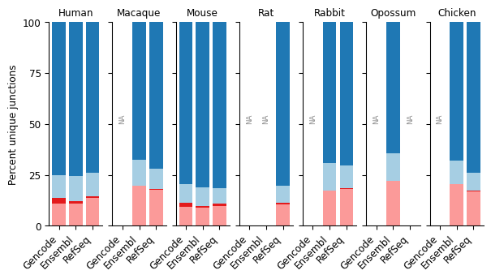

(a) The productivity split is robust to the choice of annotation source.

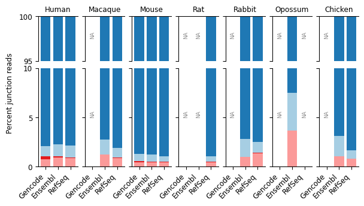

(b)

Figure 4

# Splicing versus expression

## Fig 3d — adult brain vs adult kidney

```python
bk = pd.read_csv(f"{OUT}/DataForReplotting_BetaBeta_AdultBrainKidney.tsv.gz", sep="\t")
recs = []
for sp in ["Chicken", "Human"]:
    for cod in ["Productive", "Unproductive"]:
        s = bk[(bk.Species == sp) & (bk.Prod == (cod == "Productive"))].dropna(
            subset=["deltapsi", "logFC"])
        from scipy.stats import spearmanr
        rho, p = spearmanr(s.deltapsi, s.logFC)
        recs.append(dict(Species=sp, Coding=cod, Prod=(cod == "Productive"),
                         n_table=contrast_n_sig("Adult Brain v Adult Kidney", sp, cod),
                         n_spearman=len(s), spearman=rho, p=p))
s_bk = pd.DataFrame(recs)
# P.adj: BH over the full 417-test contrast-summaries family (see contrast-summaries-corrected),
# not just these 4 tests -- Fig 3d is one contrast among many in that same family.
s_bk["p_adj"] = [contrast_p_adj("Adult Brain v Adult Kidney", r.Species, r.Coding)
                 for r in s_bk.itertuples()]
assert np.allclose(s_bk.p, [contrast_summaries_powered[
    (contrast_summaries_powered.Tissue == "Adult Brain v Adult Kidney")
    & (contrast_summaries_powered.Species == r.Species)
    & (contrast_summaries_powered.Coding == r.Coding)].p.iloc[0] for r in s_bk.itertuples()]), \
    "local p and contrast-summaries p disagree -- check filtering is identical"

fig, axes = plt.subplots(2, 2, figsize=(4.6, 3.4), sharex=True, sharey=True,
                         gridspec_kw={"wspace": 0.10, "hspace": 0.12})
for ri, sp in enumerate(["Chicken", "Human"]):
    for ci, cod in enumerate(["Productive", "Unproductive"]):
        ax = axes[ri, ci]
        sub = bk[(bk.Species == sp) & (bk.Prod == (cod == "Productive"))]
        ax.axhline(0, ls="--", color="0.5", lw=0.8, zorder=1)
        ax.scatter(sub.deltapsi, sub.logFC, s=3, alpha=0.05, lw=0,
                   color=CODE_COL[cod], zorder=2)
        m = sub.dropna(subset=["deltapsi", "logFC"])
        slope, intercept = np.polyfit(m.deltapsi, m.logFC, 1)
        xs = np.array([m.deltapsi.min(), m.deltapsi.max()])
        ax.plot(xs, intercept + slope * xs, color=CODE_COL[cod], lw=1.6, zorder=4)
        r = s_bk[(s_bk.Species == sp) & (s_bk.Coding == cod)].iloc[0]
        ax.text(0.02, 0.97,
                f"n={r.n_spearman}\nspearman rho={r.spearman:.2f}\n"
                f"P={pval_fmt(r.p)}\nP.adj={pval_fmt(r.p_adj)}",
                transform=ax.transAxes, ha="left", va="top", fontsize=SMALL_TXT, zorder=6)
        ax.set_ylim(-5, 5); ax.set_yticks([-4, -2, 0, 2, 4])
        if ri == 0:
            ax.set_title(cod, fontsize=AXIS_TXT)
        if ci == 1:
            ax2 = ax.twinx(); ax2.set_yticks([])
            ax2.set_ylabel(sp, fontsize=AXIS_TXT, rotation=-90, labelpad=12)
            for s_ in ax2.spines.values():
                s_.set_visible(False)
        ax.tick_params(axis="both", labelsize=AXIS_TXT)
        sns.despine(ax=ax)
for ax in axes[-1]:
    ax.tick_params(axis="x", labelrotation=45)
    for lab in ax.get_xticklabels():
        lab.set_ha("right")
fig.supylabel("Differential gene\nexpression (log$_2$FC)", fontsize=AXIS_TXT, x=-0.02, ma="center")
fig.supxlabel("Differential splicing\n(Delta PSI)", fontsize=AXIS_TXT, y=-0.10)
fig.suptitle("Adult Brain v Adult Kidney", fontsize=AXIS_TXT, y=1.02)
savefig(fig, "Fig3d_BetaBeta_AdultBrainKidney.pdf")
record_source("Fig3d", bk[["Species", "Prod", "deltapsi", "logFC"]])
s_bk_out = s_bk[["Species", "Coding", "n_table", "n_spearman", "spearman", "p", "p_adj"]].rename(
    columns={"n_spearman": "n_spearman (requires cluster can be matched to a gene)"})
record_source("Fig3d_stats", s_bk_out)
s_bk_out
```

|  | Species | Coding | n_table | n_spearman (requires cluster can be matched to a gene) | spearman | p | p_adj |
| --- | --- | --- | --- | --- | --- | --- | --- |
| 0 | Chicken | Productive | 2380 | 2263 | -0.054968 | 0.008913 | 0.029035 |
| 1 | Chicken | Unproductive | 1031 | 1026 | -0.143396 | 0.000004 | 0.000045 |
| 2 | Human | Productive | 2568 | 2437 | -0.016686 | 0.410294 | 0.572722 |
| 3 | Human | Unproductive | 318 | 275 | -0.175560 | 0.003492 | 0.013607 |

(a) Differential splicing of unproductive junctions is anticorrelated with host gene expression.

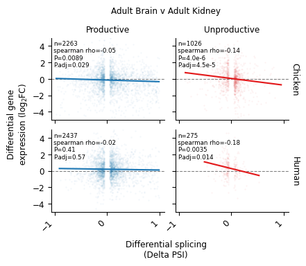

(b)

Figure 5

In both species the unproductive junctions show a negative relationship between ΔPSI and Δexpression while the productive ones show essentially none — the signature expected if increased inclusion of an unproductive junction lowers host transcript abundance.

**A note on *n*.** The *n* printed on each panel (and `n_spearman` in the source-data table) is the number of clusters actually used for the Spearman correlation and the OLS trend line — excluding clusters whose host gene has no matched expression value, since a rank correlation and a line fit cannot be computed against a missing y-value. The source-data table also lists `n_table`, the total significant differential-splicing cluster count for that species/coding class from `n_sig_productive_ds_leafcutter_clusters` / `n_sig_unproductive_ds_leafcutter_clusters` in `20260820_SupplementalTable_Contrasts.tsv`, which is slightly larger and not the number plotted or tested.

**A note on *P.adj*.** This panel highlights one contrast, but its P.adj is not computed from just these 4 tests — it comes from `contrast_summaries_powered` (see the setup section above), the Benjamini-Hochberg correction over the full family of 417 well-powered splicing-vs-expression tests spanning every contrast in the supplementary table, the same family FigS23b plots in full.

## FigS23b — splicing-expression coupling, every contrast

Every contrast in the study at once: each point is one species:tissue contrast, positioned by its splicing–expression Spearman ρ and that correlation’s significance. The per-species P is a one-sided Wilcoxon rank-sum testing whether productive ρ exceeds unproductive ρ, over contrasts with at least 100 events.

```
{'Human': '1e-4', 'Macaque': '2e-4', 'Mouse': '3e-6', 'Rat': '2e-5', 'Rabbit': '0.003', 'Opossum': '0.002', 'Chicken': '0.001'}
```

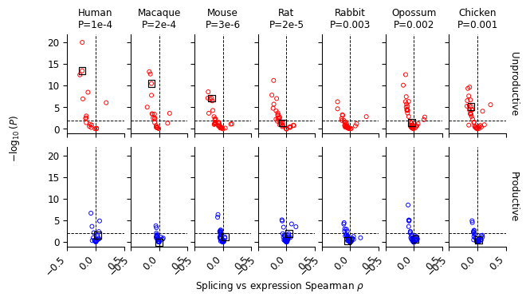

Figure 6: Splicing-expression coupling is specific to unproductive junctions in every species.

```python
volc = contrast_summaries_powered.copy()  # already n>=100, with the shared p_adj column
species_p = {}
for sp, sub in volc.groupby("Species"):
    species_p[sp] = wilcox_p(sub.loc[sub.Coding == "Productive", "spearman"].dropna(),
                             sub.loc[sub.Coding == "Unproductive", "spearman"].dropna(),
                             alternative="greater")

VOLC_COL = {"Unproductive": "red", "Productive": "blue"}
fig, axes = plt.subplots(2, 7, figsize=(7.4, 3.6), sharex=True, sharey=True,
                         gridspec_kw={"wspace": 0.12, "hspace": 0.14})
for ci, sp in enumerate(SPECIES):
    for ri, cod in enumerate(["Unproductive", "Productive"]):
        ax = axes[ri, ci]
        sub = volc[(volc.Species == sp) & (volc.Coding == cod)]
        ax.axvline(0, ls="--", color="black", lw=0.7)
        ax.axhline(2, ls="--", color="black", lw=0.7)
        ax.scatter(sub.spearman, -np.log10(sub.p), s=14, facecolors="none",
                   edgecolors=VOLC_COL[cod], lw=0.7, zorder=3)
        hi = sub[sub.Tissue == "Juvenile Testis vs Adult Testis"]
        ax.scatter(hi.spearman, -np.log10(hi.p), s=44, marker="s", facecolors="none",
                   edgecolors="black", lw=0.9, zorder=4)
        ax.set_xlim(-0.5, 0.5); ax.set_xticks([-0.5, 0, 0.5])
        ax.set_ylim(-1, 22); ax.set_yticks([0, 5, 10, 15, 20])
        ax.tick_params(axis="both", labelsize=AXIS_TXT)
        sns.despine(ax=ax)
        if ri == 0:
            ax.set_title(f"{sp}\nP={rfmt(species_p[sp])}", fontsize=AXIS_TXT)
        if ci == 6:
            ax2 = ax.twinx(); ax2.set_yticks([])
            ax2.set_ylabel(cod, fontsize=AXIS_TXT, rotation=-90, labelpad=12)
            for s_ in ax2.spines.values():
                s_.set_visible(False)
for ax in axes[1]:
    ax.tick_params(axis="x", labelrotation=45)
    for lab in ax.get_xticklabels():
        lab.set_ha("right")
fig.supylabel(r"$-\log_{10}(P)$", fontsize=AXIS_TXT, x=0.02)
fig.supxlabel(r"Splicing vs expression Spearman $\rho$", fontsize=AXIS_TXT, y=-0.06)
savefig(fig, "FigS_SplicExpr_b_Volcano_AllSpecies.pdf")
print({sp: rfmt(species_p[sp]) for sp in SPECIES})
record_source("FigS23B", volc)
```

In every species the unproductive contrasts sit left of zero and reach far higher significance than the productive ones. The highlighted squares mark the juvenile-vs-adult testis contrast.

# Testis development

Both panels take their juvenile and adult groups from the supplementary contrast table, so the sample composition of every point is traceable to a row of that file.

## Fig 3c — percent unproductive reads

Percent = unproductive reads / (unproductive + productive reads) per library. Each point is one RNA-seq library; bars are group medians and P is a two-sided Wilcoxon rank-sum.

```
{'Human': '0.002', 'Macaque': '4e-05', 'Mouse': '0.010', 'Rat': '0.004', 'Rabbit': '0.133', 'Opossum': '3e-05', 'Chicken': '0.024'}
```

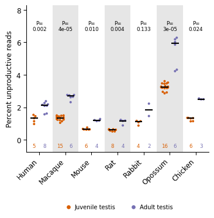

Figure 7: Unproductive splicing increases in adult testis.

```python
pct = pd.read_csv(f"{OUT}/DataToPlot.Testis.Percent.UP.tsv.gz", sep="\t").set_index("ID")

STAGES_C = ["Juvenile testis", "Adult testis"]
OFF_C = {"Juvenile testis": -0.20, "Adult testis": 0.20}
pc = samples_from_table(NEW_TESTIS_NAME)
pc["Stage"] = np.where(pc.GroupNum == 1, STAGES_C[0], STAGES_C[1])
pc = pc.merge(pct[["Percent"]], left_on="sample", right_index=True, how="left")
assert pc.Percent.notna().all(), "a contrast-table library is missing from the metric table"
pv_c = {sp: wilcox_p(pc.query("Species==@sp and Stage==@STAGES_C[0]").Percent,
                     pc.query("Species==@sp and Stage==@STAGES_C[1]").Percent)
        for sp in SPECIES}

ymax = pc.Percent.max()
fig, ax = plt.subplots(figsize=(4.2, 3.4))
shade(ax)
ax.set_xlim(-0.5, len(SPECIES) - 0.5)
ax.set_ylim(-0.75, ymax * 1.32)     # limits before layout: swarm geometry depends on them
for sp in SPECIES:
    for st in STAGES_C:
        v = pc.query("Species==@sp and Stage==@st").Percent.values
        xc = SPIDX[sp] + OFF_C[st]
        draw_swarm(ax, xc, v, STAGE_COL[st], size_pt=3.0, max_width=0.26)
        ax.plot([xc - 0.14, xc + 0.14], [np.median(v)] * 2, color="black", lw=1.6,
                zorder=4, solid_capstyle="butt")
        ax.text(xc, -0.20, str(len(v)), ha="center", va="top",
                fontsize=SMALL_TXT, color=STAGE_COL[st])
    ax.text(SPIDX[sp], ymax * 1.06, f"P=\n{pfmt(pv_c[sp])}", ha="center", va="bottom",
            fontsize=SMALL_TXT)
ax.set_xticks(range(len(SPECIES))); ax.set_xticklabels(SPECIES)
ax.set_ylabel("Percent unproductive reads", fontsize=AXIS_TXT)
ax.tick_params(axis="x", labelrotation=45, labelsize=AXIS_TXT)
ax.tick_params(axis="y", labelsize=AXIS_TXT)
for lab in ax.get_xticklabels():
    lab.set_ha("right")
ax.legend(handles=[plt.Line2D([], [], marker="o", ls="", color=STAGE_COL[s], markersize=4,
                              label=s) for s in STAGES_C],
          loc="upper center", bbox_to_anchor=(0.5, -0.32), ncol=2, frameon=False,
          fontsize=LEG_TXT, handletextpad=0.1)
sns.despine(ax=ax)
savefig(fig, "Fig3c_PercentUnproductive_Testis.pdf")
print({sp: pfmt(p) for sp, p in pv_c.items()})
record_source("Fig3c", pc[["Species", "sample", "Stage", "Percent"]])
```

## FigS20 — percent unproductive reads across species, tissues and development

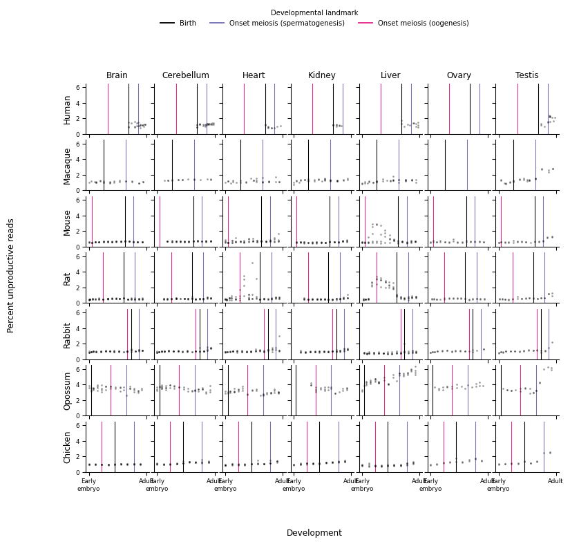

Figure 8: Percent of unproductive reads across species, tissues, and developmental time. Vertical lines mark developmental landmarks (birth, onset of meiosis) per species.

```python
alltis = pd.read_csv(f"{OUT}/DataToPlot.AllTissues.Percent.UP.tsv.gz", sep="\t")
landmarks = pd.read_csv(f"{OUT}/DataToPlot.DevelopmentalMarkers.tsv.gz", sep="\t")
TISSUES_S20 = ["Brain", "Cerebellum", "Heart", "Kidney", "Liver", "Ovary", "Testis"]
# column name -> (legend label, colour); OnsetMeiosis is the spermatogenesis landmark,
# renamed from "Onset meiosis spermatogenesis" by the developmental-markers export rule.
LANDMARK_COL = {"Birth": ("Birth", "black"),
                "OnsetMeiosis": ("Onset meiosis (spermatogenesis)", "#7570b3"),
                "Onset meiosis oogenesis": ("Onset meiosis (oogenesis)", "#e7298a")}

fig, axes = plt.subplots(len(SPECIES), len(TISSUES_S20), figsize=(9.2, 7.6), sharex=True,
                         sharey=True, gridspec_kw={"wspace": 0.08, "hspace": 0.12})
for ri, sp in enumerate(SPECIES):
    lm = landmarks[landmarks.Species == sp].iloc[0]
    for ci, ts in enumerate(TISSUES_S20):
        ax = axes[ri, ci]
        sub = alltis[(alltis.Species == sp) & (alltis.Tissue == ts)]
        for col, (_, color) in LANDMARK_COL.items():
            if col in lm.index and pd.notna(lm[col]):
                ax.axvline(lm[col], color=color, lw=0.8, zorder=1)
        ax.scatter(sub.PercentRank_OrdinalStage, sub.Percent, s=4, alpha=0.4,
                   color="black", lw=0, zorder=2)
        ax.set_ylim(0, 6.5); ax.set_xlim(-0.05, 1.05)
        ax.tick_params(axis="both", labelsize=SMALL_TXT)
        sns.despine(ax=ax)
        if ri == 0:
            ax.set_title(ts, fontsize=AXIS_TXT)
        if ci == 0:
            ax.set_ylabel(sp, fontsize=AXIS_TXT)
        else:
            ax.tick_params(labelleft=False)
        if ri == len(SPECIES) - 1:
            ax.set_xticks([0, 1]); ax.set_xticklabels(["Early\nembryo", "Adult"])
fig.supylabel("Percent unproductive reads", fontsize=AXIS_TXT, x=-0.005)
fig.supxlabel("Development", fontsize=AXIS_TXT, y=-0.02)
fig.legend(handles=[plt.Line2D([], [], color=color, lw=1.4, label=label)
                    for label, color in LANDMARK_COL.values()],
           loc="upper center", bbox_to_anchor=(0.5, 1.04), ncol=3, frameon=False,
           fontsize=LEG_TXT, title="Developmental landmark", title_fontsize=LEG_TXT)
savefig(fig, "FigS20_PercentUnproductive_AllTissues.pdf")
record_source("FigS20", alltis[["Species", "Tissue", "ID", "PercentRank_OrdinalStage",
                                "Percent"]])
```

## Fig 3f — *ARHGAP17* unproductive junction

*ARHGAP17* carries an exon-skipping junction classified as unproductive in all seven species. PSI is shown only for libraries with at least 10 reads in the cluster.

The early-embryo group is arm 1 of the `Early embryo Testis v Adult Testis` contrast, which has no human row — hence “(non-human)” in the legend. That contrast and the juvenile/adult one are defined independently and are **not disjoint**: a few macaque and opossum libraries belong to both and are drawn twice under two colours, which is why the green and orange opossum clouds coincide. They are left duplicated rather than silently de-duplicated so each group matches its contrast definition exactly.

```
libraries listed under two stage groups: {'Macaque': 3, 'Opossum': 10}
```

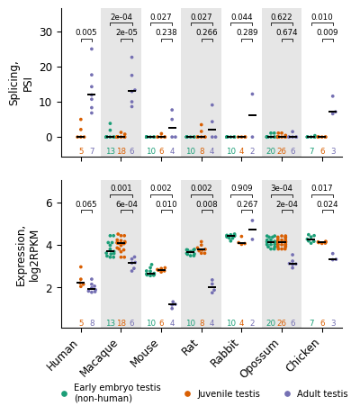

Figure 9: ARHGAP17 unproductive junction PSI and host gene expression across testis development.

```python
examples = pd.read_csv(f"{OUT}/DataForReplotting_ConservedAS_Examples.tsv.gz", sep="\t")
arh = examples[examples.gene_name == "ARHGAP17"].copy()
arh["PSI_shown"] = np.where(arh.ReadsInClusterGroup, arh.PSI, np.nan)

STAGES_F = ["Early embryo testis", "Juvenile testis", "Adult testis"]
ee = samples_from_table("Early embryo Testis v Adult Testis", 1).assign(
    Stage="Early embryo testis")
ja = samples_from_table(NEW_TESTIS_NAME)
ja["Stage"] = np.where(ja.GroupNum == 1, "Juvenile testis", "Adult testis")
pf = pd.concat([ee, ja], ignore_index=True)[["Species", "sample", "Stage"]]
_ov = pf.groupby(["Species", "sample"]).size().rename("n").reset_index().query("n > 1")
print("libraries listed under two stage groups:", _ov.groupby("Species").size().to_dict())

pf = pf.merge(arh[["ID", "Species.short", "PSI_shown", "log2RPKM"]],
              left_on=["sample", "Species"], right_on=["ID", "Species.short"], how="inner")


def group_vals(sp, stage, col):
    return pf.query("Species==@sp and Stage==@stage")[col].dropna().values


pf_p = {}
for sp in SPECIES:
    for col in ["PSI_shown", "log2RPKM"]:
        for lab, (g1, g2) in {"Juv_v_Ad": ("Juvenile testis", "Adult testis"),
                              "EE_v_Ad": ("Early embryo testis", "Adult testis")}.items():
            a_, b_ = group_vals(sp, g1, col), group_vals(sp, g2, col)
            pf_p[(sp, col, lab)] = wilcox_p(a_, b_) if len(a_) and len(b_) else np.nan

OFF_F = {"Early embryo testis": -0.27, "Juvenile testis": 0.0, "Adult testis": 0.27}
fig, axes = plt.subplots(2, 1, figsize=(4.2, 4.8), sharex=True,
                         gridspec_kw={"hspace": 0.16})
for ax, (col, ylab) in zip(axes, [("PSI_shown", "Splicing,\nPSI"),
                                  ("log2RPKM", "Expression,\nlog2RPKM")]):
    sub = pf.dropna(subset=[col])
    lo, hi = sub[col].min(), sub[col].max(); span = hi - lo
    shade(ax)
    ax.set_xlim(-0.5, len(SPECIES) - 0.5)
    ax.set_ylim(lo - span * 0.22, hi + span * 0.46)
    for sp in SPECIES:
        for st in STAGES_F:
            v = group_vals(sp, st, col)
            if not len(v):
                continue
            xc = SPIDX[sp] + OFF_F[st]
            draw_swarm(ax, xc, v, STAGE_COL[st], size_pt=2.8, max_width=0.19)
            ax.plot([xc - 0.10, xc + 0.10], [np.median(v)] * 2, color="black", lw=1.5,
                    zorder=4, solid_capstyle="butt")
            ax.text(xc, lo - span * 0.12, str(len(v)), ha="center", va="top",
                    fontsize=SMALL_TXT, color=STAGE_COL[st])
        for k, (lab, x1, x2) in enumerate(
                [("Juv_v_Ad", SPIDX[sp] + OFF_F["Juvenile testis"],
                  SPIDX[sp] + OFF_F["Adult testis"]),
                 ("EE_v_Ad", SPIDX[sp] + OFF_F["Early embryo testis"],
                  SPIDX[sp] + OFF_F["Adult testis"])]):
            p = pf_p[(sp, col, lab)]
            if np.isnan(p):
                continue
            y = hi + span * (0.09 + 0.18 * k)
            ax.plot([x1, x1, x2, x2], [y, y + span * 0.03, y + span * 0.03, y],
                    color="black", lw=0.6, zorder=5)
            ax.text((x1 + x2) / 2, y + span * 0.045, pfmt(p), ha="center", va="bottom",
                    fontsize=SMALL_TXT, zorder=5)
    ax.set_ylabel(ylab, fontsize=AXIS_TXT)
    ax.tick_params(axis="y", labelsize=AXIS_TXT)
    sns.despine(ax=ax)
axes[1].set_xticks(range(len(SPECIES))); axes[1].set_xticklabels(SPECIES)
axes[1].tick_params(axis="x", labelrotation=45, labelsize=AXIS_TXT)
for lab in axes[1].get_xticklabels():
    lab.set_ha("right")
axes[1].legend(handles=[plt.Line2D([], [], marker="o", ls="", color=STAGE_COL[s],
                                   markersize=4,
                                   label="Early embryo testis\n(non-human)"
                                         if s == STAGES_F[0] else s)
                        for s in STAGES_F],
               loc="upper center", bbox_to_anchor=(0.5, -0.32), ncol=3, frameon=False,
               fontsize=LEG_TXT, handletextpad=0.1)
savefig(fig, "Fig3f_ARHGAP17_Testis.pdf")
record_source("Fig3f", pf[["Species", "sample", "Stage", "PSI_shown", "log2RPKM"]])
record_source("Fig3f_stats", pd.DataFrame(
    [{"Species": sp, "Metric": col, "Comparison": lab, "p": p}
     for (sp, col, lab), p in pf_p.items()]))
```

Inclusion of the unproductive junction rises and host-gene expression falls between juvenile and adult testis in most species, in the direction expected if the junction destabilises the transcript.

## FigS23a — juvenile vs adult testis, beta-beta

The same ΔPSI-vs-Δexpression comparison as Fig 3d, but for the `Juvenile Testis v Adult Testis` contrast in place of Adult Brain v Adult Kidney. One event per cluster, `p.adjust < 0.05` and `|ΔPSI| > 0.05`, exactly as in Fig 3d; the correct thresholds are FDR<5% and |ΔPSI|>5% throughout (the published legend’s “FDR < 0.05%” is a typo).

```python
jat = pd.read_csv(f"{OUT}/DataForReplotting_BetaBeta_JuvenileAdultTestis.tsv.gz", sep="\t")
recs = []
for sp in ["Chicken", "Human"]:
    for cod in ["Productive", "Unproductive"]:
        s = jat[(jat.Species == sp) & (jat.Prod == (cod == "Productive"))].dropna(
            subset=["deltapsi", "logFC"])
        from scipy.stats import spearmanr
        rho, p = spearmanr(s.deltapsi, s.logFC)
        recs.append(dict(Species=sp, Coding=cod, Prod=(cod == "Productive"),
                         n_table=contrast_n_sig("Juvenile Testis v Adult Testis", sp, cod),
                         n_spearman=len(s), spearman=rho, p=p))
s_jat = pd.DataFrame(recs)
# P.adj: BH over the full 417-test contrast-summaries family, as in Fig 3d. Note the contrast
# is named "...vs..." in ContrastSummaries but "...v..." in the supplementary contrast table.
s_jat["p_adj"] = [contrast_p_adj("Juvenile Testis vs Adult Testis", r.Species, r.Coding)
                  for r in s_jat.itertuples()]
assert np.allclose(s_jat.p, [contrast_summaries_powered[
    (contrast_summaries_powered.Tissue == "Juvenile Testis vs Adult Testis")
    & (contrast_summaries_powered.Species == r.Species)
    & (contrast_summaries_powered.Coding == r.Coding)].p.iloc[0] for r in s_jat.itertuples()]), \
    "local p and contrast-summaries p disagree -- check filtering is identical"

fig, axes = plt.subplots(2, 2, figsize=(4.6, 3.4), sharex=True, sharey=True,
                         gridspec_kw={"wspace": 0.10, "hspace": 0.12})
for ri, sp in enumerate(["Chicken", "Human"]):
    for ci, cod in enumerate(["Productive", "Unproductive"]):
        ax = axes[ri, ci]
        sub = jat[(jat.Species == sp) & (jat.Prod == (cod == "Productive"))]
        ax.axhline(0, ls="--", color="0.5", lw=0.8, zorder=1)
        ax.scatter(sub.deltapsi, sub.logFC, s=3, alpha=0.05, lw=0,
                   color=CODE_COL[cod], zorder=2)
        m = sub.dropna(subset=["deltapsi", "logFC"])
        slope, intercept = np.polyfit(m.deltapsi, m.logFC, 1)
        xs = np.array([m.deltapsi.min(), m.deltapsi.max()])
        ax.plot(xs, intercept + slope * xs, color=CODE_COL[cod], lw=1.6, zorder=4)
        r = s_jat[(s_jat.Species == sp) & (s_jat.Coding == cod)].iloc[0]
        ax.text(0.02, 0.97,
                f"n={r.n_spearman}\nspearman rho={r.spearman:.2f}\n"
                f"P={pval_fmt(r.p)}\nP.adj={pval_fmt(r.p_adj)}",
                transform=ax.transAxes, ha="left", va="top", fontsize=SMALL_TXT, zorder=6)
        ax.set_ylim(-5, 5); ax.set_yticks([-4, -2, 0, 2, 4])
        if ri == 0:
            ax.set_title(cod, fontsize=AXIS_TXT)
        if ci == 1:
            ax2 = ax.twinx(); ax2.set_yticks([])
            ax2.set_ylabel(sp, fontsize=AXIS_TXT, rotation=-90, labelpad=12)
            for s_ in ax2.spines.values():
                s_.set_visible(False)
        ax.tick_params(axis="both", labelsize=AXIS_TXT)
        sns.despine(ax=ax)
for ax in axes[-1]:
    ax.tick_params(axis="x", labelrotation=45)
    for lab in ax.get_xticklabels():
        lab.set_ha("right")
fig.supylabel("Differential gene\nexpression (log$_2$FC)", fontsize=AXIS_TXT, x=-0.02, ma="center")
fig.supxlabel("Differential splicing\n(Delta PSI)", fontsize=AXIS_TXT, y=-0.10)
fig.suptitle("Juvenile Testis v Adult Testis", fontsize=AXIS_TXT, y=1.02)
savefig(fig, "FigS23a_BetaBeta_JuvenileAdultTestis.pdf")
record_source("FigS23A", jat[["Species", "Prod", "deltapsi", "logFC"]])
s_jat_out = s_jat[["Species", "Coding", "n_table", "n_spearman", "spearman", "p", "p_adj"]].rename(
    columns={"n_spearman": "n_spearman (requires cluster can be matched to a gene)"})
record_source("FigS23A_stats", s_jat_out)
s_jat_out
```

|  | Species | Coding | n_table | n_spearman (requires cluster can be matched to a gene) | spearman | p | p_adj |
| --- | --- | --- | --- | --- | --- | --- | --- |
| 0 | Chicken | Productive | 2179 | 1970 | 0.021570 | 3.386208e-01 | 5.043031e-01 |
| 1 | Chicken | Unproductive | 1581 | 1579 | -0.113418 | 6.246829e-06 | 6.512320e-05 |
| 2 | Human | Productive | 5355 | 4915 | 0.032309 | 2.350663e-02 | 6.903002e-02 |
| 3 | Human | Unproductive | 1105 | 1009 | -0.235608 | 3.409206e-14 | 7.108195e-12 |

(a) Differential splicing of unproductive junctions is anticorrelated with host gene expression through testis development, human and chicken.

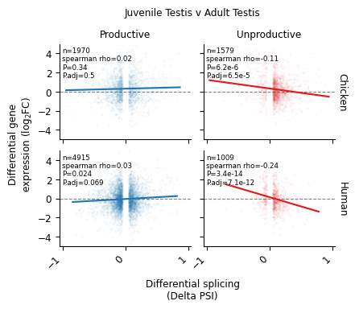

(b)

Figure 10

As in Fig 3d, the unproductive junctions show a negative ΔPSI-Δexpression relationship in both species while the productive ones do not.

**A note on *n*** (as in Fig 3d): the *n* printed on each panel (and `n_spearman` in the source-data table) is the number of clusters actually used for the Spearman correlation and trend line, after excluding clusters with no matched expression value. The source-data table also lists `n_table`, the total significant cluster count from `20260820_SupplementalTable_Contrasts.tsv`’s `n_sig_productive_ds_leafcutter_clusters` / `n_sig_unproductive_ds_leafcutter_clusters` columns for `Juvenile Testis v Adult Testis`, which is slightly larger and not the number plotted or tested.

**A note on *P.adj*** (as in Fig 3d): P.adj here is the same shared `contrast_summaries_powered` correction, i.e. Benjamini-Hochberg over all 417 well-powered tests across every contrast in the supplementary table, not just the 4 tests in this panel.

# Conserved AS events

## FigS24a — conserved-event filter cascade

Five successive filters, once down an unproductive path and once down a productive path, both starting from the junctions that lift over to a human junction. `*Any` counts distinct *human* features across all non-macaque species, so it is not the sum of the per-species bars.

```python
casc = pd.read_csv(f"{OUT}/DataToPlot.ConservedEventCascade.tsv.gz", sep="\t")
CASC_LAB = {"Macaque": "Mac", "*Any": "*Any", "Mouse": "*Mou", "Rat": "*Rat",
            "Rabbit": "*Rab", "Opossum": "*Opo", "Chicken": "*Chi"}
CASC_ORDER = ["Macaque", "*Any", "Mouse", "Rat", "Rabbit", "Opossum", "Chicken"]
STEP_TITLES = lambda w: ["Matches a human\njunction (liftOver)", f"& is {w}",
                         f"& matching human\njunction is {w}",
                         "& is appreciably\nalternatively spliced",
                         "& is tissue or developmentally\nregulated in both"]


def cascade_row(path, titles, fname, figsize=(11.5, 1.9)):
    d = casc[casc.Path == path]
    fig, axes = plt.subplots(1, 5, figsize=figsize, gridspec_kw={"wspace": 0.42})
    for ax, step, ttl in zip(axes, sorted(d.FilterStep.unique()), titles):
        st = d[d.FilterStep == step].set_index("Species")["n"]
        vals = [int(st.get(k, 0)) for k in CASC_ORDER]
        x = np.arange(len(CASC_ORDER))
        ax.bar(x, vals, width=0.8, color="#d9d9d9", edgecolor="none")
        for xi, v in zip(x, vals):
            ax.text(xi, 0, f" {v}", rotation=90, ha="center", va="bottom", fontsize=5.0)
        ax.set_xticks(x)
        ax.set_xticklabels([CASC_LAB[k] for k in CASC_ORDER], rotation=45, ha="right",
                           fontsize=SMALL_TXT)
        ax.set_ylim(0, max(vals) * 1.02)
        ax.tick_params(axis="y", labelsize=SMALL_TXT)
        ax.set_title(ttl, fontsize=4.6, pad=3)
        sns.despine(ax=ax)
    savefig(fig, fname)
    return fig


cascade_row("Unproductive", STEP_TITLES("unproductive"),
            "FigS_ConservedAS_a_UnproductiveCascade.pdf")
cascade_row("Productive", STEP_TITLES("productive"),
            "FigS_ConservedAS_a_ProductiveCascade.pdf")
record_source("FigS24A", casc)
```

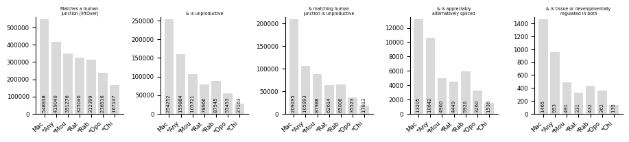

(a) Conserved-event counts after each successive filter.

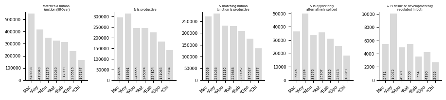

(b)

Figure 11

## FigS24c — *SCN8A* exon 18N

*SCN8A* exon 18N is a poison exon whose inclusion falls through brain development while *SCN8A* expression rises. Rows are coarse developmental stages, columns are species, colour is the group mean.

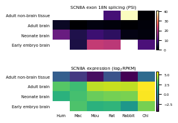

Figure 12: SCN8A exon 18N inclusion falls, and SCN8A expression rises, through brain development.

```python
GRP_MAP = {"Non brain/cerebellum adult": "Adult non-brain tissue",
           "EarlyEmbryo brain/cerebellum": "Early embryo brain",
           "Neonate brain/cerebellum": "Neonate brain",
           "Adult brain/cerebellum": "Adult brain"}
GRP_ORDER = ["Adult non-brain tissue", "Adult brain", "Neonate brain", "Early embryo brain"]
SP_C = ["Human", "Macaque", "Mouse", "Rat", "Rabbit", "Chicken"]

scn = examples[examples.gene_name == "SCN8A"].copy()
scn["PSI_shown"] = np.where(scn.ReadsInClusterGroup, scn.PSI, np.nan)
scn["Group"] = scn.NewerGroup.map(GRP_MAP)

fig, axes = plt.subplots(2, 1, figsize=(2.5, 2.3), sharex=True,
                         gridspec_kw={"hspace": 0.55})
for ax, (col, ttl, cmap) in zip(
        axes, [("PSI_shown", "SCN8A exon 18N splicing (PSI)", "magma"),
               ("log2RPKM", "SCN8A expression (log$_2$RPKM)", "viridis")]):
    m = (scn.pivot_table(index="Group", columns="Species.short", values=col,
                         aggfunc="mean")
         .reindex(GRP_ORDER).reindex(columns=SP_C))
    im = ax.imshow(m.values, aspect="auto", cmap=cmap)
    ax.set_yticks(range(len(GRP_ORDER))); ax.set_yticklabels(GRP_ORDER, fontsize=5)
    ax.set_xticks(range(len(SP_C)))
    ax.set_xticklabels(["Hum", "Mac", "Mou", "Rat", "Rabbit", "Chi"], fontsize=5)
    ax.set_title(ttl, fontsize=5.5, pad=3)
    for sp_ in ax.spines.values():
        sp_.set_visible(False)
    ax.tick_params(length=0)
    cb = fig.colorbar(im, ax=ax, fraction=0.055, pad=0.02)
    cb.ax.tick_params(labelsize=4.5)
axes[0].tick_params(labelbottom=False)
savefig(fig, "FigS_ConservedAS_c_SCN8A_Heatmaps.pdf")
record_source("FigS24C", scn[["Species.short", "Group", "PSI_shown", "log2RPKM"]])
```

## FigS24d — *SCN8A* exon conservation

Per-base PhyloP across the two constitutive flanking exons and the poison exon, coloured by codon position, with the mean over the plotted window as a dashed line. The `Mean PhyloP` annotation is the bigWig average over the whole exon and `dN/dS` comes from the exon-trio table, so both are computed over the full exon rather than the plotted window.

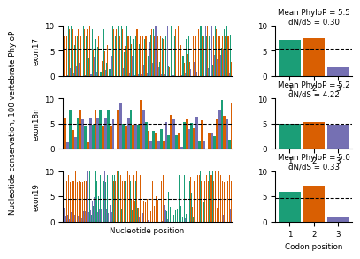

Figure 13: The SCN8A poison exon is nucleotide-conserved but not amino-acid constrained.

```python
scn_phy = pd.read_csv(f"{OUT}/DataForReplotting_SCN8A_PhyloP.tsv.gz", sep="\t")
EXON_ORDER = ["exon17", "exon18n", "exon19"]

fig, axes = plt.subplots(3, 2, figsize=(4.4, 3.0),
                         gridspec_kw={"width_ratios": [2.2, 1],
                                      "wspace": 0.35, "hspace": 0.45})
for ri, lab in enumerate(EXON_ORDER):
    w = scn_phy[scn_phy.Exon == lab]
    ax = axes[ri, 0]
    ax.bar(w.stop, w.PhyloP, width=1.0, color=[DARK2[c] for c in w.CodonPos], lw=0)
    ax.axhline(w.PhyloP.mean(), ls="--", color="black", lw=0.8)
    ax.set_ylim(0, 10); ax.set_yticks([0, 5, 10])
    ax.set_xlim(w.stop.min(), w.stop.max())
    ax.set_xticks([]); ax.set_ylabel(lab, fontsize=SMALL_TXT)
    ax.tick_params(axis="y", labelsize=SMALL_TXT); sns.despine(ax=ax)
    ax = axes[ri, 1]
    cm = w.groupby("CodonPos").PhyloP.mean()
    ax.bar(cm.index, cm.values, width=0.9, color=[DARK2[c] for c in cm.index], lw=0)
    ax.axhline(cm.mean(), ls="--", color="black", lw=0.8)
    ax.set_ylim(0, 10); ax.set_yticks([0, 5, 10])
    ax.set_xticks([0, 1, 2]); ax.set_xticklabels([1, 2, 3])
    ax.tick_params(axis="both", labelsize=SMALL_TXT); sns.despine(ax=ax)
    ax.set_title(f"Mean PhyloP = {w.MeanPhyloP_bigwig.iloc[0]:.1f}\n"
                 f"dN/dS = {w.dNdS.iloc[0]:.2f}", fontsize=SMALL_TXT, pad=2)
axes[2, 0].set_xlabel("Nucleotide position", fontsize=SMALL_TXT)
axes[2, 1].set_xlabel("Codon position", fontsize=SMALL_TXT)
fig.supylabel("Nucleotide conservation, 100 vertebrate PhyloP", fontsize=SMALL_TXT, x=-0.02)
savefig(fig, "FigS_ConservedAS_d_SCN8A_PhyloP.pdf")
record_source("FigS24D", scn_phy)
```

The poison exon (exon 18n) has mean PhyloP comparable to its constitutive neighbours but dN/dS above 1, and its conservation is flat across codon positions rather than depressed at position 3 — conserved DNA without amino-acid-level constraint.

## FigS24e — dN/dS versus PhyloP

```
highlighted: ['HNRNPL', 'PRPF39', 'RBFOX2', 'SCN1A', 'SCN8A', 'SMNDC1', 'SRRM1', 'SRRM4', 'SRSF11', 'SRSF3', 'SRSF4', 'SRSF6', 'SRSF7', 'TIAL1', 'TRA2B', 'U2AF2']
```

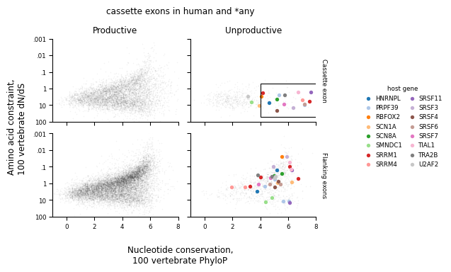

Figure 14: Unproductive cassette exons are nucleotide-conserved without amino-acid constraint.

```python
trios = pd.read_csv(f"{OUT}/DataToPlot.dNdS_PhyloP_ExonTrios.tsv.gz", sep="\t")

HL_GENES = {"SMNDC1", "SF3B1", "SCN8A", "SCN1A", "SULT4A1", "TIAL1", "TRA2B", "SRRM4",
            "PRPF39", "RBFOX2", "SRRM2", "SRRM1", "SNRPB", "ACTB", "RBM25", "U2AF2",
            "HNRNPL", "SMG7", "MYO1D"}
cand = trios[trios.external_gene_name.isin(HL_GENES)
             | trios.external_gene_name.str.contains("SRSF", na=False)]
keep_rn = cand[(cand.Productivity == "Unproductive")
               & (cand.BroadType == "Cassette exon")
               & (cand.PhyloP > 3) & (cand.dnds > 1)].rn.unique()
highlight = cand[cand.rn.isin(keep_rn)]

BT = ["Cassette exon", "Flanking exons"]; PR = ["Productive", "Unproductive"]
palette = dict(zip(sorted(highlight.external_gene_name.unique()),
                   sns.color_palette("tab20", highlight.external_gene_name.nunique())))
fig, axes = plt.subplots(2, 2, figsize=(5.0, 3.4), sharex=True, sharey=True,
                         gridspec_kw={"wspace": 0.10, "hspace": 0.14})
with np.errstate(divide="ignore"):
    for ri, bt in enumerate(BT):
        for ci, pr in enumerate(PR):
            ax = axes[ri, ci]
            s = trios[(trios.BroadType == bt) & (trios.Productivity == pr)]
            ax.scatter(s.PhyloP, -np.log10(s.dnds), s=1.5, alpha=0.05, lw=0, color="black")
            hs = highlight[(highlight.BroadType == bt) & (highlight.Productivity == pr)]
            for gname, sub in hs.groupby("external_gene_name"):
                ax.scatter(sub.PhyloP, -np.log10(sub.dnds), s=16, color=palette[gname],
                           lw=0, zorder=4, label=gname)
            if bt == "Cassette exon" and pr == "Unproductive":
                ax.add_patch(plt.Rectangle((4, -np.log10(50)), 4.5,
                                           -np.log10(0.5) + np.log10(50),
                                           fill=False, ec="black", lw=0.8, zorder=5))
            ax.set_xlim(-1, 8); ax.set_ylim(-2, 3)
            ax.set_yticks([-2, -1, 0, 1, 2, 3])
            ax.set_yticklabels(["100", "10", "1", ".1", ".01", ".001"])
            ax.tick_params(axis="both", labelsize=SMALL_TXT); sns.despine(ax=ax)
            if ri == 0:
                ax.set_title(pr, fontsize=AXIS_TXT)
            if ci == 1:
                ax2 = ax.twinx(); ax2.set_yticks([])
                ax2.set_ylabel(bt, fontsize=SMALL_TXT, rotation=-90, labelpad=12)
                for s_ in ax2.spines.values():
                    s_.set_visible(False)
fig.supxlabel("Nucleotide conservation,\n100 vertebrate PhyloP", fontsize=AXIS_TXT, y=-0.10)
fig.supylabel("Amino acid constraint,\n100 vertebrate dN/dS", fontsize=AXIS_TXT, x=-0.01)
h0, l0 = axes[0, 0].get_legend_handles_labels()
h1, l1 = axes[0, 1].get_legend_handles_labels()
seen = dict(zip(l0 + l1, h0 + h1))
fig.legend(seen.values(), seen.keys(), loc="center left", bbox_to_anchor=(1.02, 0.5),
           ncol=2, frameon=False, fontsize=SMALL_TXT, title="host gene",
           title_fontsize=SMALL_TXT, handletextpad=0.1, columnspacing=0.6)
fig.suptitle("cassette exons in human and *any", fontsize=AXIS_TXT, y=1.02)
savefig(fig, "FigS_ConservedAS_e_dNdS_v_PhyloP.pdf")
print("highlighted:", sorted(highlight.external_gene_name.unique()))
record_source("FigS24E", trios[["external_gene_name", "rn", "BroadType",
                                           "Productivity", "PhyloP", "dnds"]])
```

Unproductive cassette exons occupy a region of the plot that productive exons do not: high nucleotide conservation together with dN/dS above 1. The boxed region marks that quadrant, and the coloured points are splicing-factor and neuronal genes whose poison exons fall in it.

## FigS24f — *ARHGAP17* flanking intronic conservation

The cassette exon’s flanking intronic 50-mers are compared against the same regions of the gene’s constitutive exons, as a z-score against that null.

```
SS_Type  meanPhyloP         z            p
     SA     2.16182  7.277154 1.704684e-13
     SD     3.50082 12.063270 8.254738e-34
```

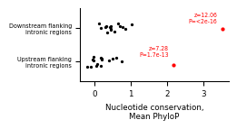

Figure 15: The ARHGAP17 cassette exon has unusually conserved flanking intronic sequence.

```python
arh_phy = pd.read_csv(f"{OUT}/DataForReplotting_ARHGAP17_FlankingPhyloP.tsv.gz", sep="\t")
arh_phy["ExNumber"] = np.ceil((np.arange(len(arh_phy)) + 1) / 2).astype(int)
arh_phy["Is_SD"] = arh_phy.groupby("ExNumber")["start"].transform("max") == arh_phy.start
arh_phy["SS_Type"] = np.where(arh_phy.Is_SD, "SD", "SA")
arh_phy = arh_phy[~((arh_phy.ExNumber == 1) & (arh_phy.SS_Type == "SA"))]
arh_phy = arh_phy[~((arh_phy.ExNumber == 17) & (arh_phy.SS_Type == "SD"))]
arh_phy["isCE"] = arh_phy.start.isin([24959620, 24959752])

null_stats = (arh_phy[~arh_phy.isCE].groupby("SS_Type").meanPhyloP
              .agg(["mean", "std"]).reset_index())
arh_phy = arh_phy.merge(null_stats, on="SS_Type")
arh_phy["z"] = (arh_phy.meanPhyloP - arh_phy["mean"]) / arh_phy["std"]
arh_phy["p"] = norm.sf(arh_phy.z)
LBL = {"SA": "Upstream flanking\nintronic regions",
       "SD": "Downstream flanking\nintronic regions"}
print(arh_phy[arh_phy.isCE][["SS_Type", "meanPhyloP", "z", "p"]].to_string(index=False))

rng = np.random.default_rng(0)
fig, ax = plt.subplots(figsize=(2.2, 1.1))
for yi, ss in enumerate(["SA", "SD"]):
    s = arh_phy[arh_phy.SS_Type == ss]
    for isce, colr, sz in [(False, "black", 6), (True, "red", 10)]:
        t = s[s.isCE == isce]
        ax.scatter(t.meanPhyloP, yi + rng.uniform(-0.15, 0.15, len(t)),
                   s=sz, color=colr, lw=0, zorder=3 if isce else 2)
        if isce and len(t):
            r = t.iloc[0]
            plab = "<2e-16" if r.p < 2e-16 else f"{r.p:.2g}"
            ax.annotate(f"z={r.z:.2f}\nP={plab}", (r.meanPhyloP, yi),
                        textcoords="offset points", xytext=(-4, 4), ha="right",
                        fontsize=4.6, color="red")
ax.set_yticks(range(2)); ax.set_yticklabels([LBL[s] for s in ["SA", "SD"]], fontsize=4.8)
ax.set_xlabel("Nucleotide conservation,\nMean PhyloP", fontsize=SMALL_TXT)
ax.tick_params(axis="x", labelsize=SMALL_TXT)
ax.set_ylim(-0.6, 1.6)
sns.despine(ax=ax)
savefig(fig, "FigS_ConservedAS_f_ARHGAP17_FlankingConservation.pdf")
record_source("FigS24F", arh_phy[["SS_Type", "isCE", "meanPhyloP", "z", "p"]])
```

The cassette exon’s flanking intronic sequence is far more conserved than that of the gene’s constitutive exons.

# NMD factor expression (FigS22a)

*UPF3A*, *UPF3B* and their ratio through testis development, expressed relative to the mean juvenile level of the same species. Juvenile and adult are the two arms of the `Juvenile Testis v Adult Testis` row of `20260820_SupplementalTable_Contrasts.tsv`, the same source Fig 3c uses, so the two panels rest on identical groups. The number of libraries in each group is printed below its box, as in Fig 3c; the ratio is formed per library, so all three gene panels use the same libraries and the counts repeat within a species.

The published version of this panel instead split juvenile from adult at the onset-of-meiosis developmental landmark. That moves one stage per species — 11 libraries in five of the seven species — across the boundary. `NMD_GroupingDiscrepancy.html` plots the panel both ways, identifies the libraries that move, and shows why.

```
Stage    Juvenile  Adult
Species
Human           5      8
Macaque        15      6
Mouse           6      4
Rat             8      4
Rabbit          4      2
Opossum        16      6
Chicken         6      3
```

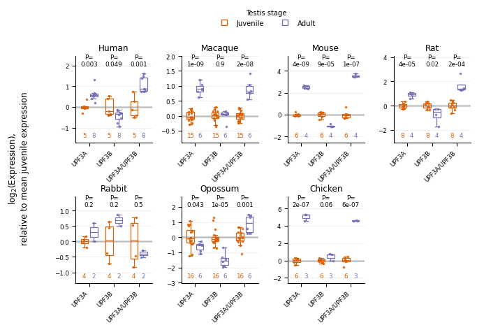

Figure 16: UPF3A rises and UPF3B falls through testis maturation in most species, shifting their ratio.

```python
nmd = pd.read_csv(f"{OUT}/DataForReplotting_NMDFactorExpression.tsv.gz", sep="\t")

GENE_ORDER = ["UPF3A", "UPF3B", "UPF3A/UPF3B"]
tst = nmd[(nmd.Tissue == "Testis") & nmd["human.name"].isin(["UPF3A", "UPF3B"])]
w = (tst.pivot_table(index=["ID", "Species", "PercentRank_OrdinalStage"],
                     columns="human.name", values="Delta").reset_index()
        .dropna(subset=["UPF3A", "UPF3B"]))
w["UPF3A/UPF3B"] = w.UPF3A - w.UPF3B
lg = w.melt(id_vars=["ID", "Species", "PercentRank_OrdinalStage"], value_vars=GENE_ORDER,
            var_name="Gene", value_name="log2FC")

# juvenile / adult from the supplementary contrast table, exactly as Fig 3c does it
ct = samples_from_table(NEW_TESTIS_NAME)
ct["Stage"] = np.where(ct.GroupNum == 1, "Juvenile", "Adult")
absent = set(ct["sample"]) - set(lg.ID)
assert not absent, f"contrast-table libraries missing from the expression table: {sorted(absent)}"
lg = (lg.merge(ct[["sample", "Stage"]], left_on="ID", right_on="sample", how="inner")
        .drop(columns="sample"))

# centre each species x gene on its own mean juvenile level
jm = (lg[lg.Stage == "Juvenile"].groupby(["Gene", "Species"])["log2FC"]
      .mean().rename("mean_juv").reset_index())
lg = lg.merge(jm, on=["Gene", "Species"])
lg["rel"] = lg.log2FC - lg.mean_juv

tt_res = {}
for (sp, gene), sub in lg.groupby(["Species", "Gene"]):
    tt_res[(sp, gene)] = ttest_ind(sub.loc[sub.Stage == "Juvenile", "log2FC"],
                                   sub.loc[sub.Stage == "Adult", "log2FC"],
                                   equal_var=True).pvalue

rng = np.random.default_rng(1)
fig, axes = plt.subplots(2, 4, figsize=(7.6, 4.4),
                         gridspec_kw={"wspace": 0.38, "hspace": 0.62})
flat = axes.ravel()
for ai, sp in enumerate(SPECIES):
    ax = flat[ai]
    sub = lg[lg.Species == sp]
    labs = dict(zip(GENE_ORDER, r_format_pval([tt_res[(sp, g)] for g in GENE_ORDER])))
    ax.axhline(0, color="black", lw=1.0, zorder=1)
    group_n = []                    # (x, stage, n) per box, labelled once ylim is known
    for gi, gene in enumerate(GENE_ORDER):
        for st in ["Juvenile", "Adult"]:
            v = sub[(sub.Gene == gene) & (sub.Stage == st)].rel.values
            if not len(v):
                continue
            xc = gi + (-0.19 if st == "Juvenile" else 0.19)
            group_n.append((xc, st, len(v)))
            bp = ax.boxplot([v], positions=[xc], widths=0.30, showfliers=False,
                            patch_artist=True, zorder=2)
            for el in ("boxes", "whiskers", "caps", "medians"):
                for a in bp[el]:
                    a.set_color(STAGE_COL[st]); a.set_linewidth(0.9)
            bp["boxes"][0].set_facecolor("none")
            ax.scatter(xc + rng.uniform(-0.10, 0.10, len(v)), v, s=7,
                       color=STAGE_COL[st], lw=0, alpha=0.85, zorder=3)
    lo, hi = sub.rel.min(), sub.rel.max(); span = hi - lo
    # extra headroom below the data for the group sizes, as in Fig 3c
    ax.set_ylim(lo - span * 0.30, hi + span * 0.34)
    for xc, st, n in group_n:
        ax.text(xc, lo - span * 0.10, str(n), ha="center", va="top",
                fontsize=SMALL_TXT, color=STAGE_COL[st])
    for gi, gene in enumerate(GENE_ORDER):
        ax.text(gi, hi + span * 0.12, f"P=\n{labs[gene]}", ha="center", va="bottom",
                fontsize=SMALL_TXT)
    ax.set_xticks(range(len(GENE_ORDER)))
    ax.set_xticklabels(GENE_ORDER, rotation=45, ha="right", fontsize=SMALL_TXT)
    ax.set_xlim(-0.55, len(GENE_ORDER) - 0.45)
    ax.set_title(sp, fontsize=AXIS_TXT)
    ax.tick_params(axis="y", labelsize=SMALL_TXT)
    ax.grid(axis="y", color="0.92", lw=0.6, zorder=0)
    sns.despine(ax=ax)
flat[-1].axis("off")
fig.supylabel("log$_2$(Expression),\nrelative to mean juvenile expression",
              fontsize=AXIS_TXT, x=-0.01, ma="center")
fig.legend(handles=[plt.Line2D([], [], marker="s", ls="", markerfacecolor="none",
                               markeredgecolor=STAGE_COL[s], markersize=6, label=s)
                    for s in ["Juvenile", "Adult"]],
           loc="upper center", bbox_to_anchor=(0.5, 1.06), ncol=2, frameon=False,
           fontsize=LEG_TXT, title="Testis stage", title_fontsize=LEG_TXT)
savefig(fig, "FigS_NMD_UPF3_JuvenileVsAdult.pdf")
print(lg[lg.Gene == GENE_ORDER[0]].groupby(["Species", "Stage"]).size()
        .unstack("Stage").reindex(SPECIES)[["Juvenile", "Adult"]].to_string())
record_source("FigS22A", lg[["ID", "Species", "Gene", "Stage", "rel"]])
record_source("FigS22A_stats", pd.DataFrame(
    [{"Species": sp, "Gene": g, "p": p} for (sp, g), p in tt_res.items()]))
```

# Panels written

```python
man = sorted(f for f in os.listdir(FIGDIR) if f.endswith(".pdf"))
pd.DataFrame({"panel": man,
              "KB": [round(os.path.getsize(os.path.join(FIGDIR, f)) / 1024, 1)
                     for f in man]})
```

|  | panel | KB |
| --- | --- | --- |
| 0 | Fig3a_TranscriptsPerGene_MainGtfs.pdf | 18.4 |
| 1 | Fig3b_PercentUniqueJuncs_MainGtfs.pdf | 12.4 |
| 2 | Fig3c_PercentUnproductive_Testis.pdf | 21.2 |
| 3 | Fig3d_BetaBeta_AdultBrainKidney.R.pdf | 339.5 |
| 4 | Fig3d_BetaBeta_AdultBrainKidney.pdf | 103.5 |
| 5 | Fig3f_ARHGAP17_Testis.pdf | 34.9 |
| 6 | FigS20_PercentUnproductive_AllTissues.pdf | 54.5 |
| 7 | FigS23a_BetaBeta_JuvenileAdultTestis.R.pdf | 526.1 |
| 8 | FigS23a_BetaBeta_JuvenileAdultTestis.pdf | 148.3 |
| 9 | FigS_AltGtfs_a_TranscriptsPerGene.pdf | 28.9 |
| 10 | FigS_AltGtfs_b_PercentUniqueJuncs.pdf | 16.4 |
| 11 | FigS_AltGtfs_c_PercentJuncReads.pdf | 18.0 |
| 12 | FigS_ConservedAS_a_ProductiveCascade.pdf | 19.2 |
| 13 | FigS_ConservedAS_a_UnproductiveCascade.pdf | 19.2 |
| 14 | FigS_ConservedAS_c_SCN8A_Heatmaps.pdf | 19.2 |
| 15 | FigS_ConservedAS_d_SCN8A_PhyloP.pdf | 25.9 |
| 16 | FigS_ConservedAS_e_dNdS_v_PhyloP.pdf | 300.1 |
| 17 | FigS_ConservedAS_f_ARHGAP17_FlankingConservati... | 15.7 |
| 18 | FigS_NMD_UPF3_JuvenileVsAdult.pdf | 45.7 |
| 19 | FigS_SplicExpr_b_Volcano_AllSpecies.pdf | 32.7 |

# Source data

One spreadsheet, one tab per panel (main-text and supplemental together), holding the exact table each panel above plots. Sheet names are truncated to Excel’s 31-character limit; the two recorded per multi-panel figure (e.g. `Fig3d` and `Fig3d_stats`) separate the raw points from the fitted/summary statistics annotated on the plot.

```python
SOURCE_DATA_XLSX = "SourceData_ComparativeSplicing.xlsx"
with pd.ExcelWriter(SOURCE_DATA_XLSX, engine="openpyxl") as xl:
    for panel, df in SOURCE_DATA.items():
        df.to_excel(xl, sheet_name=panel[:31], index=False)
print(f"{len(SOURCE_DATA)} tabs -> {SOURCE_DATA_XLSX} "
      f"({os.path.getsize(SOURCE_DATA_XLSX) / 1024:.0f} KB)")
pd.DataFrame({"panel": list(SOURCE_DATA), "n_rows": [len(d) for d in SOURCE_DATA.values()]})
```

```
21 tabs -> SourceData_ComparativeSplicing.xlsx (1562 KB)
```

|  | panel | n_rows |
| --- | --- | --- |
| 0 | Fig3a | 65 |
| 1 | FigS21A | 135 |
| 2 | Fig3b | 7 |
| 3 | FigS21B | 52 |
| 4 | FigS21C | 52 |
| 5 | Fig3d | 6297 |
| 6 | Fig3d_stats | 4 |
| 7 | FigS23B | 417 |
| 8 | Fig3c | 93 |
| 9 | FigS20 | 1695 |
| 10 | Fig3f | 176 |
| 11 | Fig3f_stats | 28 |
| 12 | FigS23A | 10220 |
| 13 | FigS23A_stats | 4 |
| 14 | FigS24A | 70 |
| 15 | FigS24C | 460 |
| 16 | FigS24D | 493 |
| 17 | FigS24E | 18918 |
| 18 | FigS24F | 32 |
| 19 | FigS22A | 279 |
| 20 | FigS22A_stats | 21 |